# Estimating fisheries sustainability index for Northern Norway

### Issues with the data:

Confirming that there are 5 extra municipalities in the landings data:

```r
extra_mun<-anti_join(fish_nor[,3], komlist[,2], by=c("Municip_name"="Name"))
unique(extra_mun)
```

```
## # A tibble: 5 x 1
##   Municip_name
##   <chr>
## 1 Beiarn
## 2 Skjerstad_2005
## 3 Harstad_2013
## 4 Bjarkoy_2013
## 5 Guovdageaidnu-Kautokeino
```

### Further data cleaning: removing locations and re-arranging locaitons

Deleting municipalities that are not in the study (Beiarn county and Guovdageaidnu-Kautokeino) Re-estimating landings for the municipalities that were merged (Bodo + Skjerstad_2005, Bjarkoy_2013 + Harstad_2013) - I sum the landings for these pairs of municipalities before they have merged.

```r
fish_nor_prep <- fish_nor %>%
                  filter(!Municip_name %in% c("Beiarn", "Guovdageaidnu-Kautokeino")) %>% #mind the correct spelling of Guo... county
                  mutate(newid = case_when(Municip_name %in% c("Harstad_2013", "Bjarkoy_2013") ~ "1",
                                           Municip_name %in% c("Bodo", "Skjerstad_2005") ~ "2",
                                           TRUE ~ Municip_name)) %>%
                  group_by(newid, Year, Species) %>%
                  mutate(Total_catch_new = sum(Total_catch))
```

And now update the whole table, where municipalities Bjarkoy_2013 and Skjerstad_2005 do not exist. In this table, Municip_name_new are the names of the municipalities after they’ve merged. Total_catch_new are the total fish landings after municipalities merging.

```r
fish_nor_prep2<- fish_nor_prep %>%
                  select(-c("Municip_name", "Total_catch")) %>%
                  mutate(Municip_name_new = newid) %>%
                  mutate(Municip_name_new = replace(Municip_name_new, Municip_name_new == "1", "Harstad")) %>%
                  mutate(Municip_name_new = replace(Municip_name_new, Municip_name_new == "2", "Bodo")) %>%
                  ungroup() %>%
                  select(c(1,2,12,3:9,11))
```

### Estimating sustainability score for each of the fish stocks

```r
fish_nor_estim <-fish_nor_prep2 %>%
                 mutate(Blim.Bmsy = Blim/Bmsy)

fish_nor_score <-fish_nor_estim %>% #estimating sustainability score for each stock (each species) - variable stock_score
                 mutate(stock_score = case_when(
                                    SSB.Bmsy >= 1 ~ 1,
                                    SSB.Bmsy < 1 & SSB.Bmsy > Blim.Bmsy ~ (SSB.Bmsy - Blim.Bmsy)/Blim.Bmsy,
                                    SSB.Bmsy <= Blim.Bmsy ~ 0
                                    ))

#write.csv(fish_nor_score, "sustain_score.csv")
```

### Estimating sustainability of fisheries in Northern Norway as score*proportion of catch

```r
fish_nor_weight <- fish_nor_score %>% #adding total weight of the catch for all stock per municipality and proportion of each stock
                   group_by(Year, Municip_number, Municip_name_new) %>%
                   mutate(total_tons = sum(Total_catch_new)) %>%
                   ungroup() %>%
                   mutate(catch_prop = Total_catch_new/total_tons,
                   catch_weighted_score = catch_prop*stock_score)

#write.csv(fish_nor_weight, "catch_weighted_score.csv")

final_scores <- fish_nor_weight %>%
                  group_by(Year, Municip_number, Municip_name_new) %>%
                  summarize(fish_score = sum(catch_weighted_score)*100)

#write.csv(final_scores, "fishery_final_score.csv")
```

### Overview of results with ggplots:

Compare total proportions of catch per stock

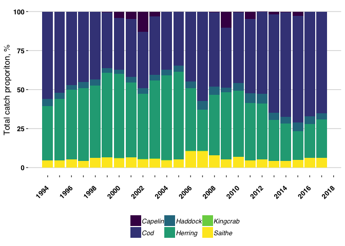

```r
breaks1 <- seq(1994, 2018, by = 1)
labels1 <- as.character(breaks1)
labels1[!breaks1%%2==0]<- ""

plot_catches <- fish_nor_weight %>%
                group_by(Year, Species) %>%
                summarize(catch_spp = sum(Total_catch_new)) %>%
                group_by(Year) %>%
                mutate(catch_grandtot = sum(catch_spp)) %>%
                ungroup() %>%
                mutate(catch_prop = (catch_spp/catch_grandtot)*100)

ggplot(plot_catches, aes(x = Year, y = catch_prop, fill= Species))+
  geom_bar(stat = "identity")+
  scale_x_continuous(breaks = breaks1, labels = labels1)+
  labs(x = "", y = "Total catch proporiton, %")+
  theme(axis.text.x = element_text(size = 10, angle = 45, hjust = 1, vjust = 0.5, face = "bold", colour = "black"),
        axis.text.y = element_text(size = 10, face = "bold",colour = "black"),
        legend.text = element_text(face = "italic"),
        legend.title = element_blank())+
  theme_hc()+
  scale_fill_viridis_d(option = "D")
```

### Total catch per species and municipality (figures are uploaded as pdf)

```r
stocks_bycounty <-fish_nor_score %>%
             mutate(county = case_when(
                                    Municip_number >= 1800 &  Municip_number < 1900 ~ "Nordland",
                                    Municip_number >= 1900 &  Municip_number < 2000 ~ "Troms",
                                    Municip_number >= 2000 ~ "Finnmark")) %>%
                                    mutate(log_catch = log(Total_catch_new + 1))


counties <- unique(stocks_bycounty$county)

#redefine breaks if needed, but they are already defined in lines 209 - 211
# breaks1 <- seq(1994, 2018, by = 1)
# labels1 <- as.character(breaks1)
# labels1[!breaks1%%2==0]<- ""

for(i in 1:length(counties))
  {
  cty <- counties[i]

  df <- stocks_bycounty %>%
    filter(county == cty)

  species <- unique(df$Species)

  for(j in 1:length(species)){
  sp <- species[j]

  df2 <- df %>%
    filter(Species == sp)

  plot <- ggplot(df2)+
      geom_col(aes(x = Year, y = log_catch), fill = "dodgerblue4")+
      facet_wrap(Municip_name_new  ~ .) +
     # scale_y_continuous(limits = c(0,10))+
      scale_x_continuous(breaks = breaks1, labels = labels1)+
      labs(y = "log(Total catch)", x = "") +
      ggtitle(paste(cty, "_", sp))+
      theme_stata(scheme = "s1color") +
      theme(legend.position = "none",
            axis.text.x = element_text(size = 6, angle = 90, hjust = 1, vjust = 0.5, face = "bold"),
            axis.text.y = element_text(size = 7, face = "bold", margin = margin(t = 0, r = 5, b = 0, l = 0)),
            plot.title = element_text(hjust=0.5, vjust=0.5),
            axis.ticks.x = element_line(size = 0.5),
            axis.ticks.length = unit(0.2, "cm"))


ggsave(paste0("figs/catch_", cty, "_", sp, ".pdf"), plot)

}

}
```

### How SSB per species varied accross years in relation to Blim and Bmsy?

```r
#breaks2 <- seq(1994, 2018, by = 1)
# labels1 <- as.character(breaks1)
# labels1[!breaks1%%2==0]<- ""

ices_spp <-unique(ices_clean$Species)

 ices_plotprep <- ices_clean %>%
       filter(Year == c("1994":"2017")) %>%
       select(Year, Species, SSB, Bmsy, Blim) %>%
       mutate(SSB = as.numeric(as.character(SSB))) %>%
       mutate(Year = as.numeric(as.character(Year)))

 for (i in 1:length(ices_spp)) {

 sp <-species[i]
 df <- ices_plotprep %>%
       filter(Species == sp)
 bmsy = df$Bmsy[1]
 blim = df$Blim[1]

options(scipen = 999)

plot2 <- ggplot(df)+
      geom_col(aes(x = Year, y = SSB), fill = "dodgerblue")+
      scale_x_continuous(breaks = breaks1, labels = labels1)+
      scale_y_continuous(limits = c(0,max(df$SSB, na.rm = T)))+
      labs(y = "SSB", x = "") +
      geom_hline(aes(yintercept = Blim), col = "darkred", linetype = "dashed", size = 1) +
      geom_hline(aes(yintercept = Bmsy), col = "darkgreen", linetype = "dashed", size = 1) +
      ggtitle(sp) +
      annotate("text", x = 1994, y = (bmsy + 20000), label = "Bmsy", hjust = 0, color = "darkgreen", size = 7)+
      annotate("text", x = 1994, y = (blim + 20000), label = "Blim", hjust = 0, color = "darkred", size = 7)+
      theme_stata(scheme = "s1color") +
      theme(legend.position = "none",
             axis.title = element_text(size = 15),
             axis.text.x = element_text(size = 12, angle = 45, hjust = 1, vjust = 0.5, face = "bold"),
             axis.text.y = element_text(size = 12, face = "bold", margin = margin(t = 0, r = 0, b = 0, l = 0),
                                        angle = 0, hjust = 1, vjust = 0),
             plot.title = element_text(hjust=0.5, vjust=0.5),
             axis.ticks.x = element_line(size = 0.5),
             axis.ticks.length = unit(0.2, "cm"),
             strip.text = element_text(size = 15))

ggsave(paste0("figs/SSB_", "_", sp, ".pdf"), plot2)

 }
```

### How did the fisheries sustainability score varied in Norway temporally in each municipality?

```r
plot_fscores <-final_scores %>%
             mutate(county = case_when(
                                    Municip_number >= 1800 &  Municip_number < 1900 ~ "Nordland",
                                    Municip_number >= 1900 &  Municip_number < 2000 ~ "Troms",
                                    Municip_number >= 2000 ~ "Finnmark"
                                    ))

for(i in 1:length(counties))
  {
  cty <- counties[i]

  df <- plot_fscores %>%
    filter(county == cty)

  plot <- ggplot(df)+
      geom_line(aes(x = Year, y = fish_score))+
      facet_wrap(Municip_name_new  ~ .) +
      scale_x_continuous(breaks = breaks1, limits = c(1994,2018), labels = labels1)+
      labs(y = "Fisheries sustainability score", x = "") +
      ggtitle(cty)+
      theme_stata(scheme = "s1color") +
      theme(legend.position = "none",
            axis.text.x = element_text(size = 6, angle = 90, hjust = 1, vjust = 0.5, face = "bold"),
            axis.text.y = element_text(size = 7, face = "bold", angle = 0, hjust = 1, vjust = 0),
            axis.title.y = element_text(margin = margin(t = 0, r = 10, b = 0, l = 0)),
            plot.title = element_text(hjust=0.5, vjust=0.5),
            axis.ticks.x = element_line(size = 0.5),
            axis.ticks.length = unit(0.1, "cm"))


ggsave(paste0("figs/fishery_score","_", cty, ".pdf"), plot)

}
```

### Re-estimating fisheries sustainability score by smoothing it with a rolling average (zoo package)

```r
municipalities <-unique(final_scores$Municip_name_new)

finallist <-list()
for (i in 1:length(municipalities))
  {
  mp <- municipalities[i]
  df <- final_scores %>%
      filter(Municip_name_new == mp)
   runmean <-data.frame(runmean = rollapply(df$fish_score, width = 3, FUN = mean,  fill=NA))
   df2 <- bind_cols(df, runmean)
  finallist[[i]] <- df2
}

smoothed_fish_scores <- do.call("rbind", finallist)
colSums(is.na(smoothed_fish_scores)) #a lot of NA were introduced with a rolling mean, because some municipailities have too few data lines. Does it make sense to use rolling mean then_
```

```
##             Year   Municip_number Municip_name_new       fish_score
##                0                0                0                0
##          runmean
##              162
```